# Dissertation Analysis

### County Demographics

```r
p_scores_demo_peaceful <- glm(peaceful_protest ~ mrp_ideology + percent_female +
                                perc_age_0_17 + perc_age_18_34 + perc_age_35_59 +
                                perc_age_60_74 + perc_75_up + perc_black +
                                perc_white + perc_hispanic +
                                perc_less_hs + perc_associates + perc_bachelors +
                                perc_graduate_professional + perc_not_in_labor_force +
                                median_hh_income,
                              data = peaceful_protests_prop_scores_demo,
                              family = binomial(link = "logit"))
```

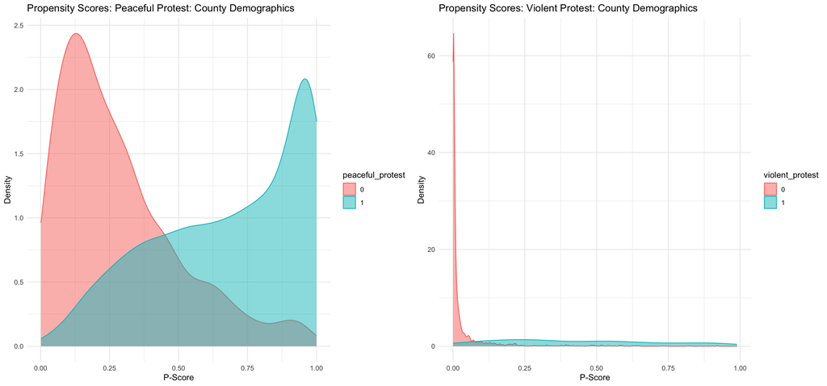

### Historical + County Demographics

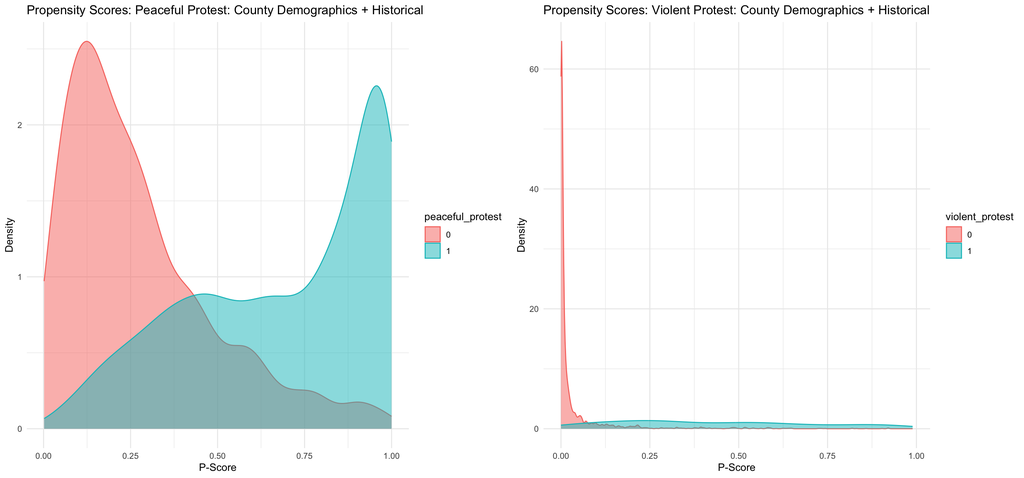

```r
p_scores_demo_hist_peaceful <- glm(peaceful_protest ~ `2010` + `2011` + `2012` +
                                `2013` + `2014` + `2015` + `2016` + `2017` +
                                `2018` + `2019` + mrp_ideology + percent_female +
                                perc_age_0_17 + perc_age_18_34 + perc_age_35_59 +
                                perc_age_60_74 + perc_75_up + perc_black +
                                perc_white + perc_hispanic +
                                perc_less_hs + perc_associates + perc_bachelors +
                                perc_graduate_professional + perc_not_in_labor_force +
                                median_hh_income,
                              data = peaceful_protests_prop_scores_demo_hist,
                              family = binomial(link = "logit"))
```

#### Question 1a: Should I use the propensity scores with just county data because it shows a better difference in propensity scores for the treatment and control groups? (This is not obvious for violent protests but it seems obvious for peaceful protests)

#### Question 1b: Given these density graphs, can I use the propensity scores with historical + county demographics for my sensitivity analysis?

## Matching

#### Question 2: I removed Percent Asian and police killings per capita because the data was highly skewed and I couldn’t get balance in the treatment and control groups. What do you think of this?

#### Question 3: One to one matching, replacement and the genetic method seems to get me closest to the difference in the groups being not significant but when I calculate the p-values, I get a lot of them less than 0.05. What is going on here? (I am using `t.test` to calculate the p-value)

```r
m_out <- MatchIt::matchit(peaceful_protest~p_score,
                          data = peaceful_protests_prop_scores_demo,
                          method = "genetic",
                          ratio = 1,
                          replace = T,
                          distance = "mahalanobis")
```

```
## The matched data set has 2057 counties. 518 are in control 1539 are in treatment. The original dataset had 3171 counties.
```

| Variable | Control_Mean | Treatment_Mean | P_Value |
| --- | --- | --- | --- |
| mrp_ideology | 0.2300237 | 0.1051840 | 0.0000000 |
| percent_female | 1.0478146 | 1.0459289 | 0.0003160 |
| perc_age_0_17 | 0.2197271 | 0.2166064 | 0.0778125 |
| perc_age_18_34 | 0.1837859 | 0.1993424 | 0.0000000 |
| perc_age_35_59 | 0.3078391 | 0.3090141 | 0.3947751 |
| perc_age_60_74 | 0.4325567 | 0.4191326 | 0.0000000 |
| perc_75_up | 0.0778868 | 0.0723690 | 0.0000000 |
| perc_black | 0.0757045 | 0.0904413 | 0.0169025 |
| perc_white | 1.0911283 | 1.1096359 | 0.0000050 |
| perc_hispanic | 0.0757044 | 0.0950271 | 0.0005670 |
| perc_less_hs | 0.0273567 | 0.0254217 | 0.0263813 |
| perc_associates | 0.0660404 | 0.0626876 | 0.0003253 |
| perc_bachelors | 0.0945632 | 0.1139957 | 0.0000000 |
| perc_graduate_professional | 0.0519820 | 0.0720840 | 0.0000000 |
| perc_not_in_labor_force | 0.5802399 | 0.5622316 | 0.0000000 |
| median_hh_income | 11.0187423 | 11.1137183 | 0.0000000 |

### First Attempt at Diff in Diff

```r
diff_diff_output <- lm(prop_police ~ peaceful_protest*time, data = diff_in_diff_df)

summary(diff_diff_output)
```

```
##
## Call:
## lm(formula = prop_police ~ peaceful_protest * time, data = diff_in_diff_df)
##
## Residuals:
##      Min       1Q   Median       3Q      Max
## -0.14082 -0.14082 -0.11678 -0.03093  0.96907
##
## Coefficients:
##                       Estimate Std. Error t value Pr(>|t|)
## (Intercept)            0.03093    0.01299   2.382   0.0173 *
## peaceful_protest       0.08585    0.01501   5.719 1.15e-08 ***
## time                   0.03477    0.01836   1.893   0.0584 .
## peaceful_protest:time -0.01073    0.02123  -0.505   0.6134
## ---
## Signif. codes:  0 '***' 0.001 '**' 0.01 '*' 0.05 '.' 0.1 ' ' 1
##
## Residual standard error: 0.2955 on 4110 degrees of freedom
## Multiple R-squared:  0.01584,    Adjusted R-squared:  0.01512
## F-statistic: 22.05 on 3 and 4110 DF,  p-value: 3.651e-14
```

#### First Attempt at Parallel Trends

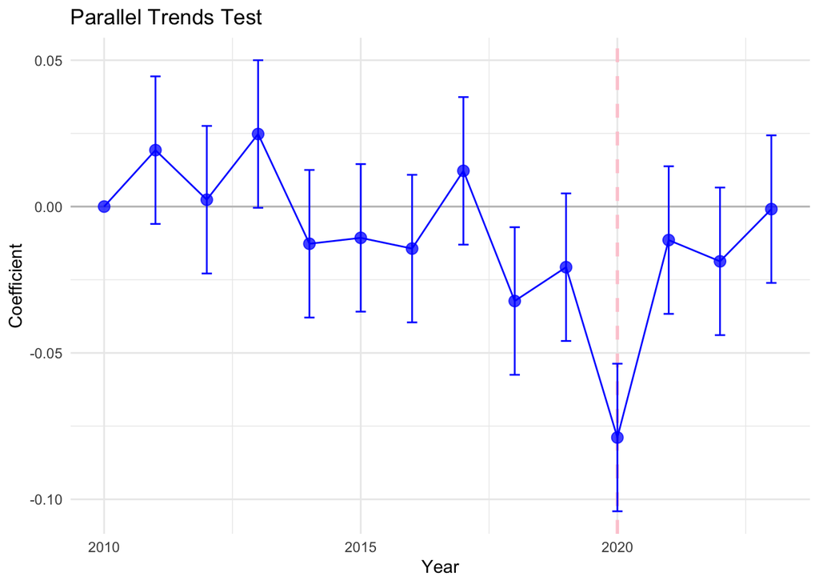

```r
parallel_trends_df <- full_protest_data %>%
  group_by(county_state, year) %>%
  summarise(prop_police = mean(prop_police, na.rm = TRUE)) %>%
  left_join(protest_data_demo) %>%
  left_join(treatment_peaceful)

# Define the regression model
reg1 <- lm(prop_police ~ peaceful_protest * factor(year), data = parallel_trends_df)

# Extract coefficients for interaction terms
coefs <- coef(reg1)[grep("peaceful_protest:factor\\(year\\)", names(coef(reg1)))]
upper <- confint(reg1, vcov. = vcovHC(reg1, type = "HC0"))[grep("peaceful_protest:factor\\(year\\)", rownames(confint(reg1))), 2]
lower <- confint(reg1, vcov. = vcovHC(reg1, type = "HC0"))[grep("peaceful_protest:factor\\(year\\)", rownames(confint(reg1))), 1]

# Create a data frame with coefficients and confidence intervals
estudy <- data.frame(
  year = as.numeric(gsub("peaceful_protest:factor\\(year\\)", "", names(coefs))),
  coefs = coefs,
  lower = lower,
  upper = upper
)

# Add a row for the baseline year
new_row <- data.frame(coefs = 0, lower = 0, upper = 0, year = 2010)
estudy <- rbind(estudy, new_row) %>% arrange(year)

# Plot the coefficients
ggplot(estudy, aes(x = year, y = coefs)) +
  geom_vline(xintercept = 2020, color = "pink", linetype = 'dashed', alpha = 0.75, size = 1) +
  geom_hline(yintercept = 0, color = "grey") +
  geom_point(color = "blue", size = 3, alpha = 0.75) +
  geom_line(color = "blue") +
  geom_errorbar(aes(ymin = lower, ymax = upper), color = "blue", width = 0.2) +
  theme_minimal() +
  labs(x = "Year", y = "Coefficient", title = "Parallel Trends Test") +
  xlim(2010, NA)
```